# Airflow obstruction (FEV1 % predicted) in adults with and without HIV

Dataset 11: HIV infection and exercise capacity

RSR feasibility analysis

2026-08-03

# Introduction

The Pittsburgh/UCSF lung-function study enrolled adults living with HIV and HIV-uninfected comparators from two US clinical centres and assessed all of them identically with a six-minute walk test, spirometry, diffusing capacity and the St George’s Respiratory Questionnaire (Fitzpatrick and colleagues, *PLOS ONE* 2019). This teaching extract holds 427 participants, 297 of them living with HIV. FEV1 expressed as a percentage of the value predicted for a person of the same age, sex and height is the standard measure of airflow limitation, and an excess burden of chronic obstructive lung disease in people living with HIV — beyond what their smoking histories would explain — is one of the more contested claims in the HIV comorbidity literature.

**Aim.** Among these adults, we examined which of HIV status, age, sex, current smoking, cumulative pack-years, blood pressure, haemoglobin and diffusing capacity are independently associated with FEV1 % predicted, mutually adjusting for the others.

This is a *Purpose 3* analysis: several predictors are of interest and the question is which remain associated with the outcome after mutual adjustment.

# Methods

**Data source.** A cross-sectional analysis of participants enrolled at two US clinical centres (Pittsburgh and San Francisco) into a cohort study of lung function in HIV. The extract contains 427 adults aged 21 to 79 and 21 variables; 297 (69.6%) are living with HIV. All measurements were made at a single study visit.

**Variables.** The outcome is `fev1_pct_predicted`, forced expiratory volume in one second as a percentage of the predicted value (observed range 28.3 to 140.9), treated as continuous. Predictors are HIV status (reference HIV-negative, the clinically unexposed group), age (years), sex (reference male, the larger group), current smoking (reference not a current smoker), cumulative smoking exposure (pack-years), systolic and diastolic blood pressure (mmHg), haemoglobin (g/dL) and DLCO as a percentage of predicted.

**Smoking is entered once, as dose plus a current-smoking indicator.** The shipped `smoking_status` variable has three levels (never 132, former 106, current 189) and `pack_years` is **exactly zero for all 132 never-smokers and strictly positive for every ever-smoker**, so the two encode the same never/ever distinction twice. Entering the untouched factor alongside pack-years would force the former- and current-smoker contrasts to be estimated at zero pack-years, a value no ever-smoker in this sample has. We therefore keep `pack_years` as the cumulative-dose term and add one binary indicator for *current* smoking, which captures the acute airway inflammation that lifetime dose does not.

**Variables deliberately excluded.** `cd4_count`, `on_antiretroviral` and `viral_load_detectable` are **missing by design** for participants without HIV; including any of them deletes most or all of the HIV-negative comparison group and with it the exposure contrast this analysis exists to make. `mmrc_dyspnoea` is excluded because all 111 of its missing values fall in HIV-positive participants, and because breathlessness is a consequence of airflow limitation rather than a cause of it. The SGRQ scores and `six_min_walk_m` are likewise downstream of lung function and are analysed as separate outcomes.

**Statistical analysis.** `lm()`, justified because the outcome is a continuous, roughly symmetric percentage (skewness -0.43). We fitted a univariable model for each predictor first, then a single multivariable model containing all of them. Predictors were chosen in advance on subject-matter grounds, not by significance. Significance threshold 0.05; estimates are reported with 95% confidence intervals. Assumptions were checked with `performance::check_model()` and `check_collinearity()`. Analysis used R version 4.6.0 (2026-04-24) with tidyverse, gtsummary and performance.

**Parameter budget.** The model estimates 9 parameters on 410 complete cases, about 46 observations per parameter, well inside the 10-15 rule.

**Missing data.** Complete-case analysis: 410 of 427 rows were analysed (17 dropped). The outcome itself is 98.8% complete (5 missing); the rest of the loss is haemoglobin (9 missing), blood pressure (3) and DLCO (2). The analytic sample keeps 284 participants with HIV and 126 without.

# Results

## Sample characteristics

**Table 1. Sample characteristics (complete-case analytic sample).**

| **Characteristic** | **N** | **N = 410**<sup>1</sup> |
| --- | --- | --- |
| FEV1 (% predicted) | 410 | 92 (78, 104) |
| Living with HIV | 410 | 284 (69%) |
| Age (years) | 410 | 52 (45, 57) |
| Sex | 410 |  |
| Male |  | 254 (62%) |
| Female |  | 156 (38%) |
| Current smoker | 410 | 181 (44%) |
| Smoking (pack-years) | 410 | 7 (0, 23) |
| Systolic BP (mmHg) | 410 | 125 (115, 138) |
| Diastolic BP (mmHg) | 410 | 80 (72, 88) |
| Haemoglobin (g/dL) | 410 | 13.90 (12.70, 14.80) |
| DLCO (% predicted) | 410 | 81 (70, 91) |

<sup>1</sup> Median (Q1, Q3); n (%)

Median FEV1 is 92% of predicted, so the typical participant has normal airflow, but the range runs from 28% to 141% and 109 (27%) fall below the conventional 80% cut-off. Median DLCO is lower, at 81% of predicted, which is the signature of this population: gas transfer is more impaired than airflow.

## Exploratory figure

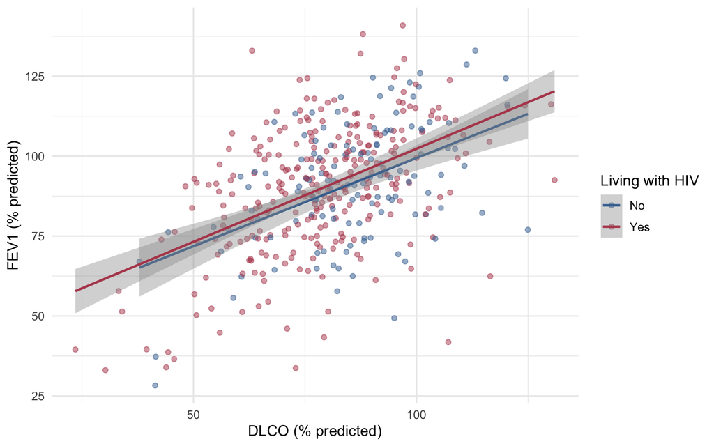

Figure 1. FEV1 (% predicted) against diffusing capacity, by HIV status.

FEV1 rises steadily with diffusing capacity, and the two fitted lines lie almost on top of one another, which already suggests that HIV status will add little once gas transfer is accounted for.

## Univariable models

| **Characteristic** | **N** | **Beta** | **95% CI** | **p-value** |
| --- | --- | --- | --- | --- |
| Living with HIV | 410 |  |  |  |
| No |  | — | — |  |
| Yes |  | -1.5 | -5.6, 2.7 | 0.5 |
| Age (years) | 410 | -0.28 | -0.46, -0.10 | 0.003 |
| Sex | 410 |  |  |  |
| Male |  | — | — |  |
| Female |  | 4.9 | 1.0, 8.8 | 0.014 |
| Current smoker | 410 |  |  |  |
| No |  | — | — |  |
| Yes |  | -4.0 | -7.8, -0.20 | 0.039 |
| Smoking (pack-years) | 410 | -0.29 | -0.40, -0.18 | <0.001 |
| Systolic BP (mmHg) | 410 | 0.02 | -0.10, 0.14 | 0.8 |
| Diastolic BP (mmHg) | 410 | 0.00 | -0.18, 0.18 | >0.9 |
| Haemoglobin (g/dL) | 410 | -1.3 | -2.5, -0.19 | 0.022 |
| DLCO (% predicted) | 410 | 0.56 | 0.46, 0.66 | <0.001 |

Abbreviation: CI = Confidence Interval

Diffusing capacity is by far the strongest crude correlate: each additional percentage point of predicted DLCO is associated with 0.56 percentage points (95% CI 0.46 to 0.66) of predicted FEV1 (p <0.001). Smoking follows, with each pack-year associated with -0.29 percentage points (95% CI -0.40 to -0.18) (p <0.001) and current smokers -4.02 percentage points (95% CI -7.84 to -0.20) (p = 0.039) below non-current smokers. Each additional year of age is associated with -0.28 percentage points (95% CI -0.46 to -0.10) (p = 0.003), women average 4.92 percentage points (95% CI 1.02 to 8.82) relative to men (p = 0.014), and each g/dL of haemoglobin -1.35 percentage points (95% CI -2.50 to -0.19) (p = 0.022). **HIV status shows no crude association at all**: -1.47 percentage points (95% CI -5.60 to 2.66) (p = 0.486). Neither blood pressure is associated.

## Why adjustment is needed

**Cumulative smoking** confounds nearly everything here. Participants with HIV have smoked more (mean 14.5 pack-years versus 11.4), pack-years is one of the strongest crude predictors of FEV1, and it is also strongly related to diffusing capacity, so it sits between HIV status, DLCO and the outcome. **Sex** is the second variable that must be handled explicitly, and it does something counter-intuitive: because FEV1 is already expressed as a percentage of a sex-specific predicted value, the residual sex difference reflects who smokes and how much rather than body size, and men in this sample are both more likely to be in the HIV-positive group (65% versus 54%) and to have higher haemoglobin. **Haemoglobin** is a third: it differs sharply by sex (median 14.5 g/dL in men versus 12.8 in women) and is lower in people with chronic infection, so a crude haemoglobin-FEV1 association is largely a sex and chronic-illness association. Mutual adjustment lets each estimate be read as a comparison between participants alike on the other measured characteristics.

## Multivariable model

| **Characteristic** | **Beta** | **95% CI** | **p-value** |
| --- | --- | --- | --- |
| Living with HIV |  |  |  |
| No | — | — |  |
| Yes | 2.0 | -1.7, 5.7 | 0.3 |
| Age (years) | -0.06 | -0.24, 0.12 | 0.5 |
| Sex |  |  |  |
| Male | — | — |  |
| Female | -2.3 | -6.3, 1.8 | 0.3 |
| Current smoker |  |  |  |
| No | — | — |  |
| Yes | 0.53 | -3.2, 4.2 | 0.8 |
| Smoking (pack-years) | -0.11 | -0.22, 0.00 | 0.060 |
| Systolic BP (mmHg) | -0.01 | -0.16, 0.13 | 0.9 |
| Diastolic BP (mmHg) | 0.02 | -0.19, 0.22 | 0.9 |
| Haemoglobin (g/dL) | -1.6 | -2.8, -0.37 | 0.010 |
| DLCO (% predicted) | 0.55 | 0.44, 0.66 | <0.001 |

Abbreviation: CI = Confidence Interval

**Model fit: multivariable linear model for FEV1 (% predicted)**

| Statistic | Value |
| --- | --- |
| Complete-case N | 410 |
| Parameters (excl. intercept) | 9 |
| Observations per parameter | 45.6 |
| R-squared | 0.265 |
| Adjusted R-squared | 0.248 |
| Residual SE (% predicted) | 17.0 |

The model explains 26.5% of the variance in FEV1 % predicted (adjusted R-squared 0.248), with a residual standard deviation of 17.0 percentage points. Diffusing capacity dominates: among participants of the same age, sex, HIV status, smoking history, blood pressure and haemoglobin, each additional percentage point of predicted DLCO is associated with 0.55 percentage points (95% CI 0.44 to 0.66) of predicted FEV1 (p <0.001). Haemoglobin is independently associated at -1.56 percentage points (95% CI -2.76 to -0.37) per g/dL (p = 0.010). Cumulative smoking is borderline, -0.11 percentage points (95% CI -0.22 to 0.00) per pack-year (p = 0.060). **HIV status remains null**: 1.97 percentage points (95% CI -1.72 to 5.66) (p = 0.296) — the point estimate has changed sign relative to the crude estimate but the confidence interval comfortably spans zero in both. Age (-0.06 percentage points (95% CI -0.24 to 0.12)), sex (-2.26 percentage points (95% CI -6.35 to 1.84)), current smoking (0.53 percentage points (95% CI -3.18 to 4.24)) and both blood pressures are not independently associated. These are associations among the participants observed, not effects of intervening.

## Unadjusted versus adjusted

**Table 2. Unadjusted and adjusted estimates.**

| **Characteristic** | **Unadjusted** **N** | **Unadjusted** **Beta** | **Unadjusted** **95% CI** | **Unadjusted** **p-value** | **Adjusted** **Beta** | **Adjusted** **95% CI** | **Adjusted** **p-value** |
| --- | --- | --- | --- | --- | --- | --- | --- |
| Living with HIV | 410 |  |  |  |  |  |  |
| No |  | — | — |  | — | — |  |
| Yes |  | -1.5 | -5.6, 2.7 | 0.5 | 2.0 | -1.7, 5.7 | 0.3 |
| Age (years) | 410 | -0.28 | -0.46, -0.10 | 0.003 | -0.06 | -0.24, 0.12 | 0.5 |
| Sex | 410 |  |  |  |  |  |  |
| Male |  | — | — |  | — | — |  |
| Female |  | 4.9 | 1.0, 8.8 | 0.014 | -2.3 | -6.3, 1.8 | 0.3 |
| Current smoker | 410 |  |  |  |  |  |  |
| No |  | — | — |  | — | — |  |
| Yes |  | -4.0 | -7.8, -0.20 | 0.039 | 0.53 | -3.2, 4.2 | 0.8 |
| Smoking (pack-years) | 410 | -0.29 | -0.40, -0.18 | <0.001 | -0.11 | -0.22, 0.00 | 0.060 |
| Systolic BP (mmHg) | 410 | 0.02 | -0.10, 0.14 | 0.8 | -0.01 | -0.16, 0.13 | 0.9 |
| Diastolic BP (mmHg) | 410 | 0.00 | -0.18, 0.18 | >0.9 | 0.02 | -0.19, 0.22 | 0.9 |
| Haemoglobin (g/dL) | 410 | -1.3 | -2.5, -0.19 | 0.022 | -1.6 | -2.8, -0.37 | 0.010 |
| DLCO (% predicted) | 410 | 0.56 | 0.46, 0.66 | <0.001 | 0.55 | 0.44, 0.66 | <0.001 |

Abbreviation: CI = Confidence Interval

Three predictors move a long way toward the null and lose significance. **Current smoking** collapses from -4.02 percentage points (95% CI -7.84 to -0.20) crude (p = 0.039) to 0.53 percentage points (95% CI -3.18 to 4.24) adjusted (p = 0.781) — essentially all of it was cumulative dose, which the pack-years term now holds constant. **Age** falls from -0.28 percentage points (95% CI -0.46 to -0.10) (p = 0.003) to -0.06 percentage points (95% CI -0.24 to 0.12) (p = 0.501), because older participants in this sample have both more pack-years and lower diffusing capacity. **Sex** reverses direction, from women averaging 4.92 percentage points (95% CI 1.02 to 8.82) crude (p = 0.014) to -2.26 percentage points (95% CI -6.35 to 1.84) adjusted (p = 0.279); women in this sample have smoked less (mean 11.4 versus 14.9 pack-years) and have better gas transfer (mean DLCO 86% versus 78% of predicted), and once those are held constant the crude female advantage disappears.

One estimate moves *away* from the null. **Haemoglobin** goes from -1.35 percentage points (95% CI -2.50 to -0.19) crude (p = 0.022) to -1.56 percentage points (95% CI -2.76 to -0.37) adjusted (p = 0.010) — already significant crudely, and strengthened by adjustment because sex was partly masking it: men have higher haemoglobin but, once smoking and DLCO are held constant, no better airflow. A negative coefficient here is not a physiological claim about oxygen carriage; it is more likely confounding by body habitus and by the smoking-related polycythaemia that accompanies chronic airflow limitation.

Two estimates barely move. **DLCO** goes from 0.56 percentage points (95% CI 0.46 to 0.66) to 0.55 percentage points (95% CI 0.44 to 0.66) and remains the dominant term, and **HIV status** stays null throughout (-1.47 percentage points (95% CI -5.60 to 2.66) crude, 1.97 percentage points (95% CI -1.72 to 5.66) adjusted) — this is a genuine negative finding rather than an artefact of confounding, and it is the interesting result of this analysis.

## Diagnostics

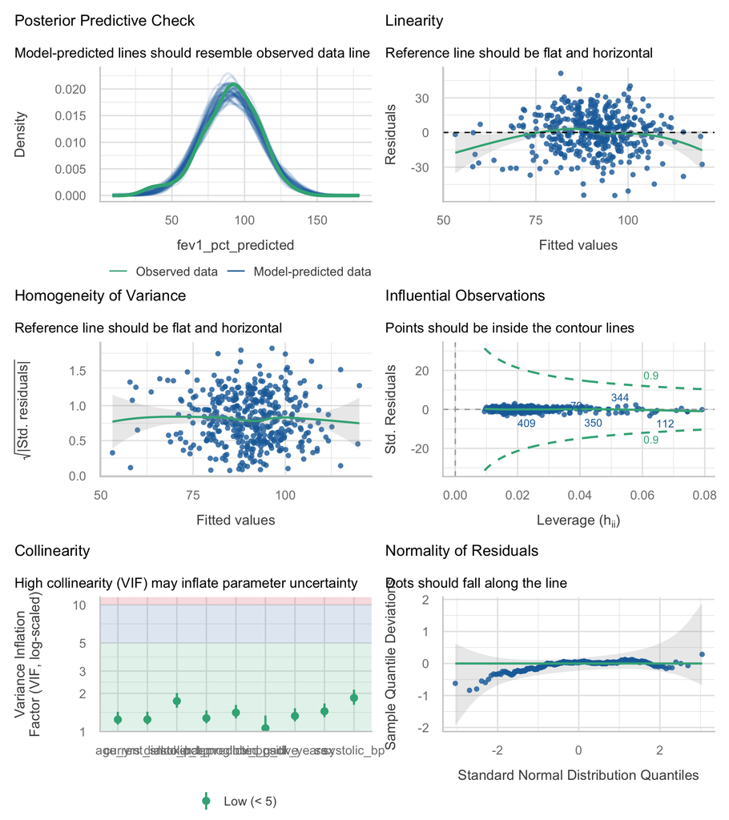

| Term | VIF | VIF_CI_low | VIF_CI_high | SE_factor | Tolerance | Tolerance_CI_low | Tolerance_CI_high |
| --- | --- | --- | --- | --- | --- | --- | --- |
| hiv_positive | 1.062724 | 1.011643 | 1.337916 | 1.030885 | 0.9409784 | 0.7474310 | 0.9884913 |
| age_yrs | 1.242604 | 1.136571 | 1.430959 | 1.114721 | 0.8047617 | 0.6988320 | 0.8798392 |
| sex | 1.445952 | 1.299476 | 1.664069 | 1.202477 | 0.6915860 | 0.6009366 | 0.7695407 |
| current_smoker | 1.244811 | 1.138295 | 1.433366 | 1.115711 | 0.8033348 | 0.6976587 | 0.8785067 |
| pack_years | 1.326922 | 1.203348 | 1.525592 | 1.151921 | 0.7536236 | 0.6554831 | 0.8310147 |
| systolic_bp | 1.843618 | 1.625613 | 2.137590 | 1.357799 | 0.5424117 | 0.4678167 | 0.6151524 |
| diastolic_bp | 1.740255 | 1.540499 | 2.013836 | 1.319187 | 0.5746285 | 0.4965648 | 0.6491403 |
| haemoglobin_g_dl | 1.409734 | 1.270083 | 1.621594 | 1.187322 | 0.7093536 | 0.6166771 | 0.7873500 |
| dlco_pct_predicted | 1.274904 | 1.161951 | 1.466636 | 1.129117 | 0.7843725 | 0.6818323 | 0.8606212 |

```
## OK: Error variance appears to be homoscedastic (p = 0.940).
```

The diagnostics are good. The residual-versus-fitted panel is flat and `check_heteroscedasticity()` does not reject constant variance (p = 0.940), and the posterior-predictive check reproduces the observed distribution closely. The normal-QQ panel shows mild deviation in the tails and `check_normality()` rejects at the 0.05 level (p = 0.030); with 410 observations this has little practical bearing on the confidence intervals, and the outcome is close enough to symmetric (skewness -0.43) that no transformation is indicated.

Collinearity is unremarkable *because FVC was excluded*. The largest variance inflation factor in the model is 1.84, for systolic blood pressure, nowhere near the conventional threshold of 5, and the DLCO term sits at 1.27. Had FVC been included, the model would still not have shown alarming VIFs — the problem it creates is not inflation but redundancy, and it is documented in the Feasibility notes. No observation exceeds the Cook’s distance contours (maximum 0.073).

# Discussion

In this two-centre US sample, **HIV status was not associated with airflow obstruction**, either crudely (-1.47 percentage points (95% CI -5.60 to 2.66)) or after adjustment for age, sex, smoking, blood pressure, haemoglobin and diffusing capacity (1.97 percentage points (95% CI -1.72 to 5.66)). What does predict FEV1 is diffusing capacity — each percentage point of predicted DLCO is worth about 0.55 percentage points of predicted FEV1 — and, marginally, cumulative tobacco dose. This is a clean negative finding: in a population where gas transfer *is* clearly worse among people with HIV (see `dlco_pct_predicted.Rmd` in this folder), spirometric airflow is not. Practically, it argues that the lung problem in treated HIV is not primarily an obstructive one, and that a normal FEV1 in a person with HIV does not rule out clinically important lung disease.

**Limitations.** Participants were recruited at **two clinical centres, Pittsburgh and UCSF, and the site variable is not in this deposit**, although the source paper shows site matters; it is therefore an unmeasured confounder and an ignored clustering variable, so the standard errors are probably optimistic. The design is cross-sectional, so nothing here speaks to the *rate* of FEV1 decline, which is where an HIV effect would most plausibly show up; a null cross-sectional difference is entirely compatible with faster decline over time. Smoking is measured as self-reported status and pack-years with no biochemical verification, and misreporting would bias the smoking coefficients toward the null and leave residual confounding in the HIV estimate. Adjusting for DLCO is arguably adjusting for a parallel consequence of the same lung injury rather than a confounder, which makes the DLCO coefficient descriptive rather than causal. Occupational exposures, cannabis and crack cocaine smoking, childhood respiratory illness and prior pneumonia — all relevant to airflow in this population, and the last of these specifically commoner in HIV — are not measured. Complete-case analysis dropped 17 of 427 rows (4.0%). Residuals are mildly non-normal. All estimates are associations, not causal effects.

**Future work.** Refit with study site as a fixed effect and with repeated spirometry from the parent cohort so that the rate of FEV1 decline, rather than a single cross-sectional level, becomes the outcome.

# Feasibility notes

*NOT part of a student report.*

**Feasibility Table F1. Effect of adding FVC (% predicted) to the model for FEV1 (% predicted).**

| Term | Without FVC | With FVC |
| --- | --- | --- |
| FVC (% predicted) | - | 0.968 |
| DLCO (% predicted) | 0.549 | 0.111 |
| Smoking (pack-years) | -0.110 | -0.087 |
| Living with HIV (yes) | 1.965 | 1.150 |
| Haemoglobin (g/dL) | -1.565 | -0.339 |

R-squared without FVC: **0.265**; with FVC: **0.776**. Residual SE falls from 17.0 to 9.4 percentage points.

- **USABLE, with one large caveat: the headline result is a null.** The diagnostics pass, the complete-case N is 410 of 427, collinearity is unremarkable and the model is honest — but the exposure of primary interest, `hiv_positive`, is not associated with the outcome either crudely (p = 0.486) or adjusted (p = 0.296). Students who expect to “find something” about HIV will be disappointed, and weak ones will start dredging. It is a genuinely good negative result and worth flagging in the brief as such.
- **MAJOR trap: `fvc_pct_predicted` on the right-hand side.** FEV1 and FVC as percentages of predicted correlate at 0.868 and are two readings from the same manoeuvre. Feasibility Table F1 shows that adding FVC lifts R-squared from 0.265 to 0.776 with an FVC coefficient of 0.97 — indistinguishable from 1, i.e. the model has discovered that FEV1 % predicted is approximately FVC % predicted — while the DLCO coefficient falls from 0.55 to 0.11 and haemoglobin becomes non-significant. Note that the VIFs stay modest, so a student who only checks collinearity will see nothing wrong: this trap is invisible to VIF and has to be caught by thinking about what the variables are. `fev1_fvc_ratio` is worse still, being the outcome divided by FVC.
- **FATAL if any HIV-restricted variable is used.** `cd4_count`, `on_antiretroviral` and `viral_load_detectable` exist only for the 297 participants with HIV. Adding `on_antiretroviral` takes the complete-case N from 410 to 284 with **0 HIV-negative participants remaining**, so `lm()` cannot fit `hiv_positive` at all; adding `cd4_count` takes N to 292 with only 20 HIV-negative participants left, and fails silently. `six_min_walk_m.Rmd` in this folder tabulates the damage.
- **MINOR: `mmrc_dyspnoea` is differentially missing** — all 111 missing values are HIV-positive participants, and adding it would take N to 302. It is also downstream of the outcome.
- **MINOR: `pack_years` and `smoking_status` are structurally entangled** (`pack_years == 0` is exactly `smoking_status == "never"` on all 427 rows). Either parameterisation works; the choice must be justified. Note that with this outcome the *current smoking* term is entirely absorbed by pack-years on adjustment (-4.02 percentage points (95% CI -7.84 to -0.20) to 0.53 percentage points (95% CI -3.18 to 4.24)), so a student who uses only `smoking_status` will report no smoking association at all and one who uses only `pack_years` will report a borderline one.
- **MINOR: mildly non-normal residuals** (p = 0.030); variance is constant (p = 0.940) and no transformation is needed.
- **Complete-case N 410 of 427** (4.0% lost); the outcome itself is only 5 rows short of complete.
- **Structural: two-site recruitment with no site variable.** Unfixable from the shipped file; belongs in Limitations. It matters more here than elsewhere, because a null result is exactly what unmeasured between-site heterogeneity would manufacture.